# Chybovost alternativně napájených tabel

## Úvod

S modernizací dopravního systému přichází potřeba digitalizace. Staré papírové jízdní řády přestávají být *v kurzu*, protože jsou náchylné vlivům počasí, je nutné je pravidelně obměňovat a cestující z nich vyčtou pouze předpokládaný čas odjezdu.  
Digitální sloupky jsou oproti tomu interaktivní, ukazují příjezdy včetně aktuálního zpoždění a změnu jízdních řádů na nich vyřešíme pouze změnou dat, která do nich posíláme.

Obyčejné digitální sloupky používající LED displaye se *z kurzu* začínají vytrácet, protože přes všechna svá pozitiva spotřebovávají moc elektřiny. Společnost ROPID proto začala používat sloupky s technologii CHLCD. Tyto displaye spotřebují mnohem méně energie, protože dokáží zobrazovat odjezdy i když jsou vypnuté. Elektřinu potřebují pouze pro překreslení zobrazovaných údajů, k čemuž dochází jen jednou za minutu.  
Aby byla úspora energie maximální experimentuje se s alternativními způsoby napájení a to pomocí solárních panelů a napájením z *nočního proudu* - z proudu, který se používá pro veřejné osvětlení a je tedy velmi levný, protože baterie těchto sloupků ho spotřebuje minimálně.

## Cíl

Poskytnout přehled o současné situaci. O počtu sloupků, o využití alternativního napájení a především o počtu chyb, které na těchto sloupcích vznikají. Rád bych vizualizoval, k jakému druhu chyb dochází na jakém druhu sloupků. Ke kolika chybám dojde v Praze a ke kolika v Příbrami. Chci zjistit, jestli vznik chyby závisí na čase, protože zvláště u solárně napájených sloupků se taková věc dá předpokládat. Nakonec se podívám na chování naměřených teplot na sloupcích.

## Přehled

V první řadě bych rád uvedl nějaké údaje.

```r
# Celkový počet sloupků
all_count
```

```
[1] 29
```

```r
# Počet sloupků se solárním napájením
sol_count
```

```
[1] 8
```

```r
# Počet sloupků s nočním napájením
nig_count
```

```
[1] 14
```

Nyní pro přehled uvedu graf, který znázorňuje rozdělení sloupků mezi Prahu a Příbram a zároveň jejich napájení. Dále se už budeme zabývat jen tably s alternativním napájením.

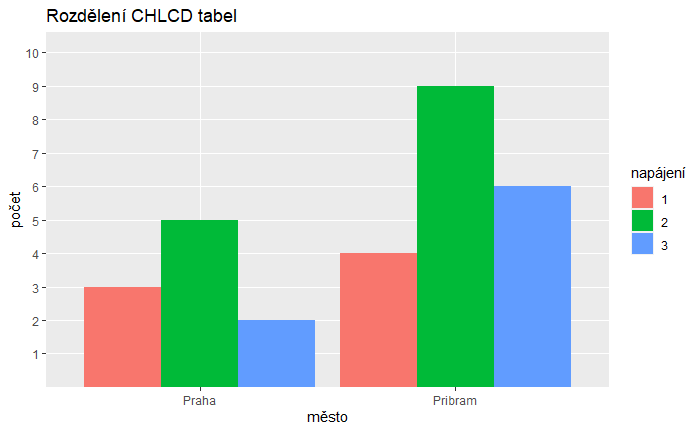

```r
pl_dist <- ggplot(data = tabs) + geom_bar(mapping = aes(x = location, fill = factor(supply)), position = "dodge")
pl_dist + labs(title = "Rozdělení CHLCD tabel", fill = "napájení",
               x = "město", y = "počet")+
  scale_y_discrete(limits = factor(1:10))
```

```r
# Supply = 1 ... trvalé napájení
# Supply = 2 ... noční napájení
# Supply = 3 ... solární napájení
```

## Jak jsou sloupky vlastně spolehlivé?

Mým původním záměrem bylo ukázat chyby rozdělené do měsíců a následně se jimy zabývat dále. Jak ale ukáže následující graf, není to tak jednoduché.

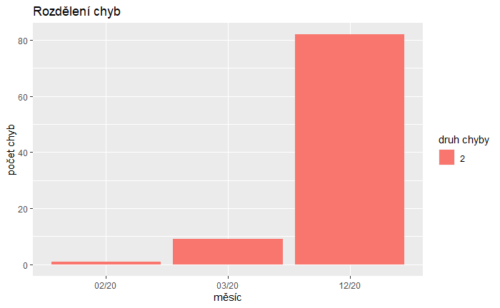

```r
# draw a histogram
ggplot(data = err_data) +
  geom_bar(mapping = aes(x = factor(format(as.Date(time),"%m/%y")),
                         fill = factor(Error)), position = "dodge") +
  labs(x = "měsíc", y = "počet chyb", title = "Rozdělení chyb",
       fill = "druh chyby")
```

```r
# Celkový počet záznamů
data_count
```

```
[1] 379705
```

```r
# Celkový počet chyb
err_count
```

```
[1] 92
```

```r
# Počet chyb vyjádřený vůči počtu záznamů
err_count/data_count
```

```
[1] 0.0002422934
```

Na 92 chybách bych moc zajímavostí neukázal. Dovolím si tedy uměle poupravit definice tabel. Limitní hodnoty posunu o 10%, což nám dá hezký náhled na to, jak přesně jsou původní limity nastaveny. Zároveň z toho můžeme vyčíst, jak často se tabla blíží k chybě, ale nakonec k ní nedojde. Rozdělení chyb potom vypadá následovně:

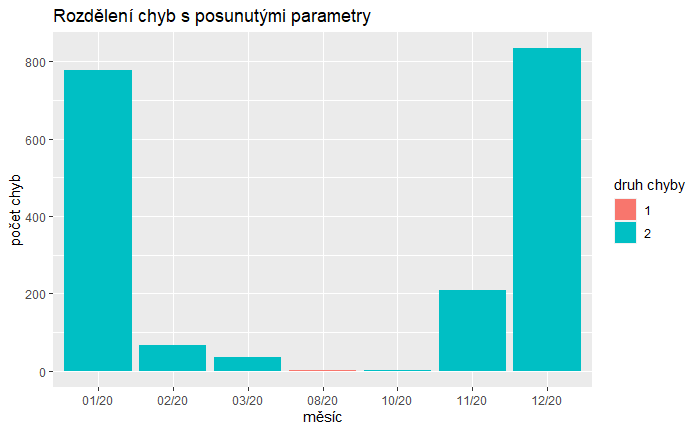

```r
# draw a histogram
ggplot(data = data_10) +
  geom_bar(mapping = aes(x = factor(format(as.Date(time),"%m/%y")),
                         fill = factor(Error)), position = "dodge") +
  labs(x = "měsíc", y = "počet chyb", fill = "druh chyby",
       title = "Rozdělení chyb s posunutými parametry")
```

```r
# chyba = 1 ... příliš vysoká teplota
# chyba = 2 ... příliš nízké napětí
```

```r
# Celkový počet chyb
err_count
```

```
[1] 1928
```

```r
# Podíl chyb
err_count/data_count
```

```
[1] 0.005077626
```

Všimněme si, že snížení teplotního limitu o `~5°` má na počet chyb velmi malý vliv, zatímco zvýšení minimálního napětí o `~1.1V` se projeví hodně.

## Práce s chybami

Nyní přistoupíme ke zpracování chyb.

### Závislost chyb na čase

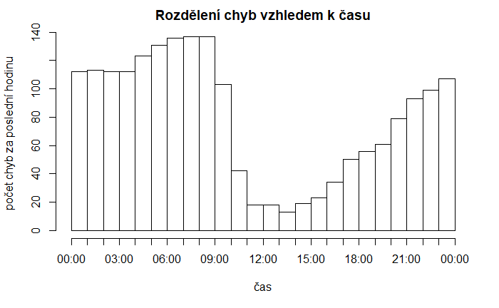

```r
# group all errors in one day, so the histogram will work as intended
data_10$hm <- as.POSIXct(paste0("2020-01-01 ",
            (str_extract(data_10$time, "..:..:.."))))

# draw the histogram
hist(x = data_10$hm,
     breaks = "hours",
     freq = T,
     main = "Rozdělení chyb vzhledem k času",
     xlab = "čas",
     ylab = "počet chyb za poslední hodinu")
```

Histogram napovídá, že větší četnost chyb máme v noci, pozdě večer a hlavně brzy ráno. Zajímá nás tedy, zda jsou cyby opravdu závislé na čase.

```r
hours <- sprintf("2020-1-1 %d:00", seq(0,24))
halfs <- sprintf("2020-1-1 %d:30", seq(0,23))
lims <- c()
time <- c()
for (i in 1:24) {
  lims <- append(lims, hours[i])
  lims <- append(lims, halfs[i])
}
time <- lims
lims <-append(lims, hours[25])
errors <- c(1:48)

for (i in 1:48) {
  from <- as.POSIXct(lims[i])
  to <- as.POSIXct(lims[i+1])
  errors[i] <- length(filter(data_10, hm >= from & hm <= to)$table_id)
}

for (i in 1:48) {
  time[i] <- hour(time[i]) + minute(time[i]) / 60
}
time_num <- as.numeric(time)

relation <- lm(errors~time_num)
summary(relation)
```

```
Call:
lm(formula = errors ~ time_num)

Residuals:
    Min      1Q  Median      3Q     Max
-32.515 -18.585   2.243  16.899  30.206

Coefficients:
            Estimate Std. Error t value Pr(>|t|)
(Intercept)  56.5391     5.6128  10.073 3.23e-13 ***
time_num     -1.3934     0.4115  -3.386  0.00146 **
---
Signif. codes:  0 ‘***’ 0.001 ‘**’ 0.01 ‘*’ 0.05 ‘.’ 0.1 ‘ ’ 1

Residual standard error: 19.75 on 46 degrees of freedom
Multiple R-squared:  0.1995,    Adjusted R-squared:  0.1821
F-statistic: 11.47 on 1 and 46 DF,  p-value: 0.00146
```

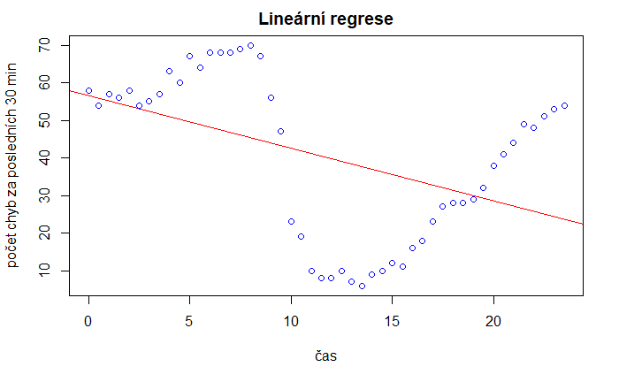

```r
plot(x = time_num, y = errors, col = "blue", abline(relation, col = "red"),
     main = "Lineární regrese",
     xlab = "čas",
     ylab = "počet chyb za posledních 30 min")
```

`p-value = 0.00146 < 0.05` Test pomocí lineární regrese nám tedy potvrdil závislost dat, ale zároveň bychom neměli zapomínat, že se nejedná o nejlepší možnou aproximaci. Vzhledem ke tvaru, který by měla křivka proložená daty, bychom lepší aproximace dosáhli npř. pomocí vhodně posunuté fce `sin(x)`. (Podobně jako v následujícím grafu.)

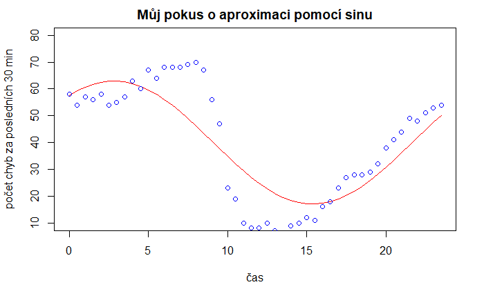

```r
plot(time_num, 23*sin(0.25*time_num+26)+40, type = "l", col = "red",
     ylim = range(10:80),
     main = "Můj pokus o aproximaci pomocí sinu",
     xlab = "čas",
     ylab = "počet chyb za posledních 30 min")
points(time_num, errors, col = "blue")
```

### Rozdělení chyb vzhledem k napájení

Omlouvám se, ale u tohoto grafu nemůžu nastavit název, protože jeho přidání zmenší vykreslenou oblast a přestanou se zobrazovat chyby typu 1, kterých je opravdu málo (v součtu 2).

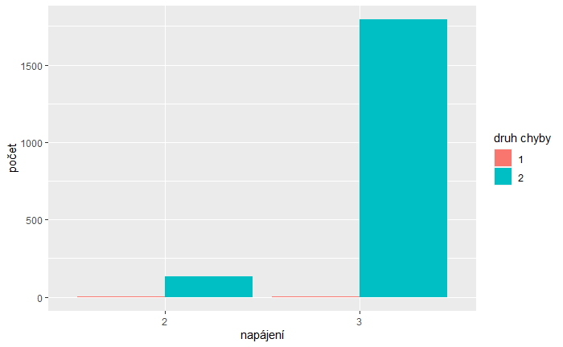

```r
err_sup_dist <- ggplot(data = data_10) +
  geom_bar(mapping = aes(x = as.character(supply), fill = factor(Error)),
  position = "dodge")
err_sup_dist + labs(fill = "druh chyby", x = "napájení", y = "počet")
```

```r
# chyba = 1 ... příliš vysoká teplota
# chyba = 2 ... příliš nízké napětí
```

### Rozdělení chyb vzhledem k umístění sloupku

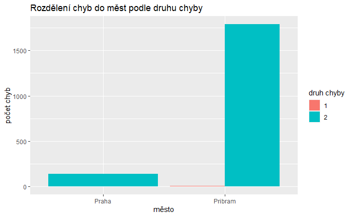

```r
par(mfrow = c(1,2))
err_loc_err_dist + labs(title = "Rozdělení chyb do měst podle druhu chyby",
                        fill = "druh chyby", x = "město", y = "počet chyb")
```

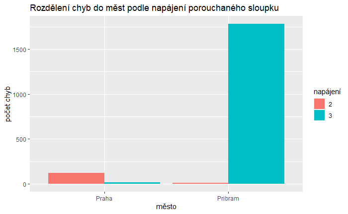

```r
# chyba = 1 ... vysoká teplota
# chyba = 2 ... nízké napětí

err_loc_sup_dist + labs(title = "Rozdělení chyb do měst podle napájení porouchaného sloupku",
                        fill = "napájení", x = "město", y = "počet chyb")
```

```r
# napájení = 2 ... noční proud
# napájení = 3 ... solární
```

### Závěr

```
graf 1 = Rozdělení chyb vzhledem k času
graf 2 = Lineární regrese
graf 3 = Rozdělení chyb vzhledem k napájení
graf 4 = Rozdělení chyb do měst podle druhu chyby
graf 5 = Rozdělení chyb do měst podle napájení porouchaného sloupku
```

Když se podíváme na `1.` graf, můžeme říci následující.  
Výskyt chyby závisí na čase. Nejvíce chyb nastává hluboko v noci nebo brzy ráno, což je doba, kdy solárně napájeným tablům dochází baterka. Nočně napájená tabla se v tu dobu naopak nabíjejí a k nízkému napětí by na nich tedy docházet nemělo.

Tomu odpovídá i `3.` graf, ze kterého vyčteme, že většina chyb nízkého napětí nastává na solárně nabíjených sloupcích. Znovu si také můžeme všimnou k jak malému množství chyb vysoké teploty dochází.

K posledním dvěma grafům bych rád připomněl jiný hned z přehledu, ve kterém jsem ukázal, rozdělení solárních a nočních sloupků mezi Prahu a Příbram.

```
Praha: 2 solární, 5 nočních
Příbram: 6 solárních, 9 nočních
```

Ze `4.` grafu vidíme, že v Příbrami došlo k mnohem více chybám v napětí, než v Praze. Dejme to do souvislosti s grafem `3.` a uvědomme si, že většina chyb v napětí pochází ze solárně napájených tabel. Nyní bychom si mohli říct, že v Příbrami je o 4 solárně napájená tabla víc a že proto je tam o tolik víc chyb v napětí.  
Graf `5.` ale tento mylný předpoklad vyvrací, protože jak můžeme vidět, většina chyb, které vznikly na území Prahy a o nichž už víme, že jsou převážně způsobeny nízkým napětím, nastala na tablech s nočním napájením.

### Shrnutí k chybám

Jak můžeme vidět ze všech předchozích dat, u solárně napájených sloupků je riziko vzniku chyby výrazně větší než u těch napájených nočně.

Právě proto bychom měli ocenit jejich konstrukci a velmi dobré nastavení limitů, které naprostou většinu těchto chyb nedopustí, jak jsme ostatně viděli v části Jak jsou sloupky vlastně spolehlivé?.

## Rozdělení naměřených teplot

Když jsem zkoumal data o teplotách napadlo mě, jestli náhodou nemají normální rozdělení. Přecejen na přednášce jsem si říkali že spousta věcí v přírodě má normální rozdělení, tak proč ne teplota. Abych si mohl tuhle teorii ověřit chyběl mi už jen odhad průměrné teploty.

Ze [stránek českého hydrometeorologického ústavu](https://www.chmi.cz/historicka-data/pocasi/uzemni-teploty#) jsem vzal průměrnou teplotu v Praze a Středočeském kraji za rok 2020. `μ = 9.9°C`

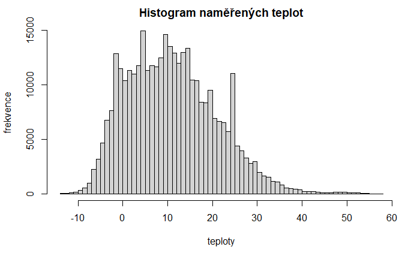

```r
hist(data[["TemperatureIn"]], breaks = 100,
     main = "Histogram naměřených teplot",
     xlab = "teploty",
     ylab = "frekvence")
```

```r
t.test(x = data[["TemperatureIn"]], mu = 9.9)
```

```
    One Sample t-test

data:  data[["TemperatureIn"]]
t = 94.96, df = 349385, p-value < 2.2e-16
alternative hypothesis: true mean is not equal to 9.9
95 percent confidence interval:
 11.45961 11.52535
sample estimates:
mean of x
 11.49248
```

`p-value < 0.05` Platí tedy alternativní hypotéza, že když se na data díváme jako na normálně rozdělenou náhodnou veličinu, její střední hodnota není 9.9°C. Místo toho jsme se dozvěděli, že s pravděpodobností 95% se střední hodnota našeho normálního rozdělení náchází na intervalu `(11.45°C, 11.53°C)`